|  | Home | EDA Cleanse | EDA Analysis | Feature Engineering | ML Models - Logistical Regression | ML Models - Decision Tree | ML Models - Random Forest | Model Demonstration |
| --- | --- | --- | --- | --- | --- | --- | --- | --- |

# Salifort Motors - ML Modelling - Random Forest

### Document Information

| Document Title | Salifort Motors - ML Modelling - Random Forest |
| --- | --- |
| Author | Rod Slater |
| Version | 1.0 |
| Created | 01-11-2023 |
| Modified | 16-11-2023 |

### Client Details

| Client Name | Salifort Motors |
| --- | --- |
| Client Contact | Mr HR Team |
| Client Email | hr@salifortmotors.it |
| Client Project | HR Team Data Driven Solutions from Machine Learning Models |

### Document Overview

ML Modelling using Random Forest for HR Data provided by Salifort Motors. This notebook details the Random Forest Modelling process and performance comparisons

### Notes

- The fit process for RandomForest models can take a long time to run, suggest using pickle save and load.
- Remember to use unique variable names for the different models.
- The GridSearch can take 20-30 mins, suggest using the `refit` option flags in this code once the model has been fitted and saved once.
- Salifort Motors - ML Modelling - Random Forest
  - Document Information
  - Client Details
  - Document Overview
  - Notes
  - Initialise Notebook
    - Import Packages
    - Set Pandas Options
    - Initialise Notebook Options
    - Define Functions
      - beepr() - make a beep when cell complete (typically fit ops)
      - display_results() - Function to retrieve scores from Results.csv and display them
      - format_GS_results(model_name: str, model_object: object, metric: str) - Function to get scores from Gridsearch
      - make_lr_results(model_name: str, model_object: object, X_var: str, y_var: str, y_pred_var: str)
      - classification_report_summary(name: str, y_var: str, y_pred_var: str)
      - Read / Write Pickle Function
- Construct Models - RandomForest
  - Random Forest - `rf1` - All Features included
    - Import data - `rf1-ALLFeat`
    - Code flags:
    - Prepare data for modelling - `rf1-ALLFeat`
    - Isolate the outcome and feature variables - `rf1-ALLFeat`
    - Train / Test split - `rf1-ALLFeat`
    - Instantiate model - Random Forest - GridSearch - `model_rf1` - Train data
    - Fit Data - Random Forest - Grid Search - `model_rf1` - Train data
      - Read / Write Pickle
      - Get GridSearch best results - Random Forest - `model_rf1` - Train data
      - Format and Save model Scores - Random Forest - GridSearch - `model_rf1` - Train data
      - Display Results
    - Make Predictions - Random Forest - best_model - `model_rf1` - Test data
      - Classification Report
      - Format and Save model Scores - `model_rf1` - Test Data
      - Display Results
    - Display Results - Random Forest Confusion Matrix
    - Display Results - Random Forest Feature Importance
  - Random Forest - `rf2` - No Departments
    - Import Data - `rf2` - No Departments
    - Code flags:
    - Prepare data for modelling - `rf2`
    - Isolate the outcome and feature variables - `rf2`
    - Train / Test split - `rf2`
    - Instantiate model - Random Forest - GridSearch - `model_rf2` - Train data
    - Fit Data - Random Forest - Grid Search - `model_rf2` - Train data
      - Read / Write Pickle
      - Get GridSearch best results - Random Forest - `model_rf1` - Train data
      - Format and Save model Scores - Random Forest - GridSearch - `model_rf1` - Train data
      - Display Results
    - Make Predictions - Random Forest - best_model - `model_rf2` - Test data
      - Classification Report
      - Format and Save model Scores - Random Forest TEST
      - Display Results
    - Display Results - Random Forest Confusion Matrix
    - Display Results - Random Forest Feature Importance
- Review Results
  - Dataset comparison - Decision Tree
  - Model performance
- Feature Importance
  - Conclusion, model comparison - RandomForest.

## Initialise Notebook

### Import Packages

```python
# Import packages

# Data manipulation
import numpy as np
import pandas as pd

# Data visualization
import matplotlib.pyplot as plt
import seaborn as sns

# Set Options
pd.set_option('display.max_columns', None)

# Data modelling Imports
from xgboost import XGBClassifier, XGBRegressor, plot_importance

from sklearn.linear_model import LogisticRegression
from sklearn.tree import DecisionTreeClassifier
from sklearn.ensemble import RandomForestClassifier

# For metrics and helpful functions
from sklearn.model_selection import GridSearchCV, train_test_split
from sklearn.metrics import accuracy_score, precision_score, recall_score, precision_recall_fscore_support, \
f1_score, confusion_matrix, ConfusionMatrixDisplay, classification_report
from sklearn import metrics
from sklearn.metrics import roc_auc_score, roc_curve
from sklearn.tree import plot_tree
from sklearn.preprocessing import StandardScaler
from datetime import datetime as dt

import statsmodels.api as sm

# For saving models
import pickle

import shap
```

### Set Pandas Options

```python
# set Pandas Display Options
pd.options.display.float_format = '{:.2f}'.format
#pd.set_option('display.precision', 2)
pd.set_option('display.max_columns', None)
pd.set_option('display.width', 120)
```

### Initialise Notebook Options

```python
load_path = "/home/hass/Documents/Learning/Salifort-Motors-Capstone-Project/00-data_cleaned/" # Source folder for cleaned data
#save_path = "/home/hass/Documents/Learning/Salifort-Motors-Capstone-Project/04-pickle-ML-models/" # destination for pickle saved models

model_path = "/home/hass/Documents/Learning/Salifort-Motors-Capstone-Project/04-pickle-ML-models/" # path to load/save pickled models
```

### Define Functions

#### beepr() - make a beep when cell complete (typically fit ops)

```python
import chime
import time

def beepr():
    for x in range(3):
        for i in range(3):
            chime.success()
            time.sleep(0.25)
        time.sleep(1)

#beepr()
```

#### display_results() - Function to retrieve scores from Results.csv and display them

```python
def display_results():
    '''
    Load Results.csv containing store test scores, return the scores for display
    In: none
    Out: pandas df of Results,csv containing precision, recall, f1, accuracy, and AUC scores of the models
    '''
    model_results = pd.read_csv("Results.csv")
    model_results.drop(columns=['Unnamed: 0'], inplace=True)
    model_results = model_results.sort_values(by='AUC', ascending=False)

    return model_results
```

#### format_GS_results(model_name: str, model_object: object, metric: str) - Function to get scores from Gridsearch

```python
def format_GS_results(model_name: str, model_object: object, metric: str):
    '''
    Arguments:
        model_name (string): what you want the model to be called in the output table
        model_object: a fit GridSearchCV object from test data
        metric (string): precision, recall, f1, accuracy, or auc

    Returns a pandas df with the F1, recall, precision, accuracy, and auc scores
    for the model with the best mean 'metric' score across all validation folds.
    '''

    # Create dictionary that maps input metric to actual metric name in GridSearchCV
    metric_dict = {'auc': 'mean_test_roc_auc',
                   'precision': 'mean_test_precision',
                   'recall': 'mean_test_recall',
                   'f1': 'mean_test_f1',
                   'accuracy': 'mean_test_accuracy'
                  }

    # Get all the results from the CV and put them in a df
    cv_results = pd.DataFrame(model_object.cv_results_)

    # Isolate the row of the df with the max(metric) score
    best_estimator_results = cv_results.iloc[cv_results[metric_dict[metric]].idxmax(), :]

    # Extract Accuracy, precision, recall, and f1 score from that row
    auc = round(best_estimator_results.mean_test_roc_auc,3)
    f1 = round(best_estimator_results.mean_test_f1,3)
    recall = round(best_estimator_results.mean_test_recall,3)
    precision = round(best_estimator_results.mean_test_precision,3)
    accuracy = round(best_estimator_results.mean_test_accuracy,3)

    # Create table of results
    table = pd.DataFrame()
    table = pd.DataFrame({'Model': [model_name],
                          'Precision': [precision],
                          'Recall': [recall],
                          'F1': [f1],
                          'Accuracy': [accuracy],
                          'AUC': [auc]
                        })

    return table
```

#### make_lr_results(model_name: str, model_object: object, X_var: str, y_var: str, y_pred_var: str)

```python
# Get results from Logistic Regression to store in comparison table
def make_lr_results(model_name: str, model_object: object, X_var: str, y_var: str, y_pred_var: str):
    '''
    Accepts as arguments :
        model name (string) - Used as the heading in Results.csv
        model object : The ML Model
        X_var, y_var, y_pred_var the variables used in the model

    Returns a pandas df with the F1, recall, precision, and accuracy scores
    for the model with the best mean F1 score across all validation folds.
    '''

    # Get all the results from the CV and put them in a dict
    report = classification_report(y_var, y_pred_var,  output_dict=True)

    # Calculate precision, recall, and F1 score for the "True" class
    predict_precision, predict_recall, predict_f1_score, _ = precision_recall_fscore_support(y_var, y_pred_var, average=None)
    f1_true_class = round(predict_f1_score[1],3)  # Index 1 corresponds to the "True" class
    f1_false_class = round(predict_f1_score[0],3)  # Index 1 corresponds to the "True" class


    # Extract accuracy, precision, recall, and f1 score from that row
    f1 = round(report['weighted avg']['f1-score'],3)
    recall = round(report['weighted avg']['recall'],3)
    precision = round(report['weighted avg']['precision'],3)
    accuracy = round(report['accuracy'],3)
    auc = round(roc_auc_score(y_var, model_object.predict_proba(X_var)[:,1]),3)
    # Create table of results
    table = pd.DataFrame({'Model': model_name,
                          'Precision': precision,
                          'Recall': recall,
                          'F1': f1,
                          'Accuracy': accuracy,
                          'AUC': auc,
                          'Predict Leave': f1_true_class,
                          'Predict Stay' : f1_false_class
                        },
                        index=[0]
                       )

    return table
```

#### classification_report_summary(name: str, y_var: str, y_pred_var: str)

```python
def classification_report_summary(name: str, y_var: str, y_pred_var: str):
    '''
    Gather stats from predictions

    In:
        name: str    : Title for report header e.g. TEST or TRAIN
        y_var: str       : y variable
        y_pred_var: str  : y prediction Variable

    Out: Display of precision, recall, f1, accuracy, and AUC scores of the models, Weighted Average and Prediction f1 score for true/false
    '''
    targetnames = ['Predicted would not leave', 'Predicted would leave']



    print("\nClassification Report : ", name)
    print(classification_report(y_var, y_pred_var, target_names=targetnames))

    print("Recall        : {:.2f}".format(recall_score(y_var, y_pred_var)))
    print("f1_score      : {:.2f}".format(f1_score(y_var, y_pred_var)))
    print("Precision     : {:.2f}".format(precision_score(y_var, y_pred_var)))
    print("Accuracy      : {:.2f}".format(accuracy_score(y_var, y_pred_var)))

    report = classification_report(y_var, y_pred_var,  output_dict=True)

    print()
    print('\u2500' * 35)
    print("Weighted Average")
    print('\u2500' * 35)

    print("Recall        : {:.2f}".format(report['weighted avg']['recall']))
    print("f1 Score      : {:.2f}".format(report['weighted avg']['f1-score']))
    print("Precision     : {:.2f}".format(report['weighted avg']['precision']))
    print("Support       : {:.2f}".format(report['weighted avg']['support']))

      # Calculate precision, recall, and F1 score for the "True" class
    predict_precision, predict_recall, predict_f1_score, _ = precision_recall_fscore_support(y_var, y_pred_var, average=None)
    f1_true_class = predict_f1_score[1]  # Index 1 corresponds to the "True" class
    f1_false_class = predict_f1_score[0]  # Index 0 corresponds to the "False" class

    print()
    print('\u2500' * 35)
    print("Prediction F1 score")
    print('\u2500' * 35)
    print("Predict Leave : {:.2f}".format(f1_true_class))
    print("Support Stay  : {:.2f}".format(f1_false_class))
```

#### Read / Write Pickle Function

- write_pickle = Write the model
- read_pickle = Read the model

```python
def write_pickle(path, model_object, save_as:str):
    '''
    In:
        path:         path of folder where you want to save the pickle
        model_object: a model you want to pickle
        save_as:      filename for how you want to save the model

    Out: A call to pickle the model in the folder indicated
    '''

    with open(path + save_as + '.pickle', 'wb') as to_write:
        pickle.dump(model_object, to_write)

def read_pickle(path, saved_model_name:str):
    '''
    In:
        path:             path to folder where you want to read from
        saved_model_name: filename of pickled model you want to read in

    Out:
        model: the pickled model
    '''
    with open(path + saved_model_name + '.pickle', 'rb') as to_read:
        model = pickle.load(to_read)

    return model
```

# Construct Models - RandomForest

## Random Forest - `rf1` - All Features included

### Import data - `rf1-ALLFeat`

Two datasets for model performance comparison, :

- `data_cleaned_NoOl_FE_AllFeat.csv` (THIS DATA) is the full data set feature engineered with `salary` encoded to ordinal, `avg_mth_hrs` binary encoded to `overwork` and dept encoded with dummies
- `data_cleaned_NoOl_FE_NoDept.csv` is the same data with the dummy encoded dept fields removed.

`Dept` appears to have low correlation across the dataset and I'm curious how much the models are influenced with low correlation features. It turns out that low correlation features have little impact on model performance. which is no surprise really!

### Code flags:

**rerun** = flag to identify the first run of the model comparisons and write a NEW Results.csv file. 0 = first run and a new file will be created with headers / 1 = Continuation, Results will be appended to the file.

**dataset** = Text indicating which dataset is being used, added to the model description during csv save to Results.csv

**model_prefix** = text indicating which ML model is being used, added to the model description during csv save to Results.csv

**refit** = Random Forest fits with this data takes 20-30 mins. 1 = Fit Data and Pickle Save Model 0 = don't refit data, Pickle load model

**fitver** = suffix added to pickle save model file name to help distinguish rf1/rf2 and all feature or focus features datasets

```python
# Load cleaned dataset into a dataframe
print("Started / Last Run =", dt.now().strftime("%Y-%m-%d %H:%M:%S"),"\n")

# Feature engineering on salary, avg_mnth_hrs, dept, outliers removed
df1 = pd.read_csv(load_path + "data_cleaned_NoOl_FE_AllFeat.csv", index_col = False)

# model_prefix : Str prefix for results.csv added to dataset
model_prefix   = 'rf1'

# dataset : Str = dataset save name for results.csv
dataset        = 'ALLFeat'

# fitver: Str = Suffix for the pickle save filename
fitver         = 'AllFeat'

# rerun : int =  Flag to set 1 = append to Results.csv / 0 = Overwrite with new file
rerun          = 1

# refit : int - 1 = Fit Data and Save model / 0 = load model, don't fit data
refit          = 0

print("df1 - All Features - Feature engineering on salary, avg_mnth_hrs, dept. outliers removed\n")

# Display dataframe columns
print(df1.info())
```

```
Started / Last Run = 2023-11-23 09:43:14

df1 - All Features - Feature engineering on salary, avg_mnth_hrs, dept. outliers removed

<class 'pandas.core.frame.DataFrame'>
RangeIndex: 11167 entries, 0 to 11166
Data columns (total 18 columns):
 #   Column            Non-Null Count  Dtype
---  ------            --------------  -----
 0   satisfaction      11167 non-null  float64
 1   last_eval         11167 non-null  float64
 2   number_project    11167 non-null  float64
 3   tenure            11167 non-null  float64
 4   left              11167 non-null  float64
 5   promotion         11167 non-null  float64
 6   salary            11167 non-null  int64
 7   dept_accounting   11167 non-null  bool
 8   dept_hr           11167 non-null  bool
 9   dept_it           11167 non-null  bool
 10  dept_management   11167 non-null  bool
 11  dept_marketing    11167 non-null  bool
 12  dept_product_mng  11167 non-null  bool
 13  dept_randd        11167 non-null  bool
 14  dept_sales        11167 non-null  bool
 15  dept_support      11167 non-null  bool
 16  dept_technical    11167 non-null  bool
 17  overworked        11167 non-null  int64
dtypes: bool(10), float64(6), int64(2)
memory usage: 807.1 KB
None
```

### Prepare data for modelling - `rf1-ALLFeat`

```python
model_data = df1.copy()
```

### Isolate the outcome and feature variables - `rf1-ALLFeat`

```python
# Isolate the outcome variable
Y = model_data['left']

# Select & Isolate the feature variables and drop the outcome variable
X = model_data.copy()
X = X.drop('left', axis = 1)

#X = sm.add_constant(X)

X.columns
```

```
Index(['satisfaction', 'last_eval', 'number_project', 'tenure', 'promotion', 'salary', 'dept_accounting', 'dept_hr',
       'dept_it', 'dept_management', 'dept_marketing', 'dept_product_mng', 'dept_randd', 'dept_sales', 'dept_support',
       'dept_technical', 'overworked'],
      dtype='object')
```

### Train / Test split - `rf1-ALLFeat`

```python
# Prepare training and test data
X_train, X_test, y_train, y_test = train_test_split(X,Y, test_size=0.25, stratify=Y, random_state=0)
```

### Instantiate model - Random Forest - GridSearch - `model_rf1` - Train data

```python
# Instantiate model
rfc = RandomForestClassifier(random_state=0)

# Assign a dictionary of hyperparameters to search over
cv_params = {'max_depth': [3,5, None],
             'max_features': [1.0],
             'max_samples': [0.7, 1.0],
             'min_samples_leaf': [1,2,3],
             'min_samples_split': [2,3,4],
             'n_estimators': [300, 500],
             }

# Assign a dictionary of scoring metrics to capture
scoring = ('accuracy', 'precision', 'recall', 'f1', 'roc_auc')

# Instantiate GridSearch
model_rf1 = GridSearchCV(rfc, cv_params, scoring=scoring, cv=4, refit='roc_auc')
```

### Fit Data - Random Forest - Grid Search - `model_rf1` - Train data

```python
X_train.columns
```

```
Index(['satisfaction', 'last_eval', 'number_project', 'tenure', 'promotion', 'salary', 'dept_accounting', 'dept_hr',
       'dept_it', 'dept_management', 'dept_marketing', 'dept_product_mng', 'dept_randd', 'dept_sales', 'dept_support',
       'dept_technical', 'overworked'],
      dtype='object')
```

```python
%%time
print("Started / Last Run =", dt.now().strftime("%Y-%m-%d %H:%M:%S"))# Fit data
if refit == 1: # if 1, refit, we'll save the already fit model
    model_rf1.fit(X_train, y_train) # --> Wall time: 21min 5s
    beepr()

print("Finish Time =", dt.now().strftime("%H:%M:%S"))
```

```
Started / Last Run = 2023-11-23 09:43:14
Finish Time = 09:43:14
CPU times: user 564 µs, sys: 0 ns, total: 564 µs
Wall time: 489 µs
```

#### Read / Write Pickle

```python
## Write pickle

if refit == 1: # refit = 1 run the fit and save the model
    write_pickle(model_path, model_rf1, 'hr_rf1-'+fitver)
```

```python
# Read in pickle
if refit == 0: # refit = 0 load model, don't  fit the data
    model_rf1 = read_pickle(model_path, 'hr_rf1-'+fitver)
```

```python
X_train.columns
```

```
Index(['satisfaction', 'last_eval', 'number_project', 'tenure', 'promotion', 'salary', 'dept_accounting', 'dept_hr',
       'dept_it', 'dept_management', 'dept_marketing', 'dept_product_mng', 'dept_randd', 'dept_sales', 'dept_support',
       'dept_technical', 'overworked'],
      dtype='object')
```

#### Get GridSearch best results - Random Forest - `model_rf1` - Train data

```python
# Get the parameters of the best-performing model
print("Best Parameters : ", model_rf1.best_params_)

# Get the average f1 score of the best-performing model
print("Best Score      : ", model_rf1.best_score_)

# Get the best estimators of the parameters
print("Best Estimator  : ", model_rf1.best_estimator_)
```

```
Best Parameters :  {'max_depth': 5, 'max_features': 1.0, 'max_samples': 0.7, 'min_samples_leaf': 3, 'min_samples_split': 2, 'n_estimators': 300}
Best Score      :  0.9801731525800323
Best Estimator  :  RandomForestClassifier(max_depth=5, max_features=1.0, max_samples=0.7,
                       min_samples_leaf=3, n_estimators=300, random_state=0)
```

#### Format and Save model Scores - Random Forest - GridSearch - `model_rf1` - Train data

```python
pd.options.display.float_format = '{:.3f}'.format
model_rf1_results = format_GS_results(model_prefix+' - '+dataset+' - '+'GS train', model_rf1, 'auc')
model_rf1_results.to_csv("./Results.csv", mode='a', index=True, header=False)
```

#### Display Results

```python
pd.options.display.float_format = '{:.4f}'.format
print(model_rf1_results)
display_results()
```

```
                      Model  Precision  Recall     F1  Accuracy    AUC
0  rf1 - ALLFeat - GS train     0.9640  0.9080 0.9350    0.9790 0.9800
```

|  | Model | Precision | Recall | F1 | Accuracy | AUC | Predict Leave | Predict Stay |
| --- | --- | --- | --- | --- | --- | --- | --- | --- |
| 17 | rf1 - ALLFeat - test | 0.9810 | 0.9810 | 0.9810 | 0.9810 | 0.9830 | 0.9430 | 0.9890 |
| 15 | rf2 - NOdept - test | 0.9810 | 0.9810 | 0.9810 | 0.9810 | 0.9830 | 0.9430 | 0.9890 |
| 13 | rf1 - ALLFeat - test | 0.9810 | 0.9810 | 0.9810 | 0.9810 | 0.9830 | 0.9430 | 0.9890 |
| 11 | rf1 - ALLFeat - test | 0.9810 | 0.9810 | 0.9810 | 0.9810 | 0.9830 | 0.9430 | 0.9890 |
| 14 | rf2 - NOdept - GS train | 0.9640 | 0.9090 | 0.9350 | 0.9790 | 0.9810 | NaN | NaN |
| 18 | rf1 - ALLFeat - GS train | 0.9640 | 0.9080 | 0.9350 | 0.9790 | 0.9800 | NaN | NaN |
| 10 | rf1 - ALLFeat - GS train | 0.9640 | 0.9080 | 0.9350 | 0.9790 | 0.9800 | NaN | NaN |
| 16 | rf1 - ALLFeat - GS train | 0.9640 | 0.9080 | 0.9350 | 0.9790 | 0.9800 | NaN | NaN |
| 12 | rf1 - ALLFeat - GS train | 0.9640 | 0.9080 | 0.9350 | 0.9790 | 0.9800 | NaN | NaN |
| 9 | dt2 - NOdept - train | 0.9780 | 0.9790 | 0.9780 | 0.9790 | 0.9790 | 0.9350 | 0.9870 |
| 8 | dt2 - NOdept - test | 0.9780 | 0.9790 | 0.9780 | 0.9790 | 0.9790 | 0.9360 | 0.9870 |
| 6 | dt1 - ALLFeat - train | 0.9780 | 0.9790 | 0.9780 | 0.9790 | 0.9790 | 0.9350 | 0.9870 |
| 5 | dt1 - ALLFeat - test | 0.9780 | 0.9790 | 0.9780 | 0.9790 | 0.9790 | 0.9360 | 0.9870 |
| 7 | dt2 - NOdept - GS train | 0.9510 | 0.9140 | 0.9320 | 0.9770 | 0.9740 | NaN | NaN |
| 4 | dt1 - ALLFeat - GS train | 0.9510 | 0.9140 | 0.9320 | 0.9770 | 0.9740 | NaN | NaN |
| 1 | lr1 - ALLFeat - train | 0.7740 | 0.8130 | 0.7860 | 0.8130 | 0.8870 | 0.2580 | 0.8930 |
| 3 | lr2 - NOdept - train | 0.7700 | 0.8110 | 0.7830 | 0.8110 | 0.8860 | 0.2470 | 0.8920 |
| 2 | lr2 - NOdept - test | 0.7670 | 0.8060 | 0.7810 | 0.8060 | 0.8780 | 0.2480 | 0.8890 |
| 0 | lr1 - ALLFeat - test | 0.7760 | 0.8110 | 0.7880 | 0.8110 | 0.8780 | 0.2770 | 0.8910 |

### Make Predictions - Random Forest - best_model - `model_rf1` - Test data

```python
# Make predictions on test data

rf1_best_model = model_rf1.best_estimator_ # Store best model parameters for later testing
y_pred_test = rf1_best_model.predict(X_test)
```

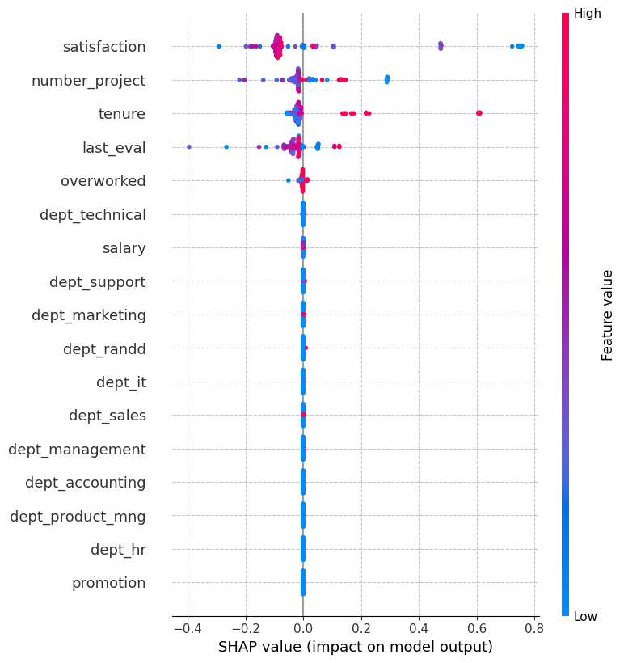

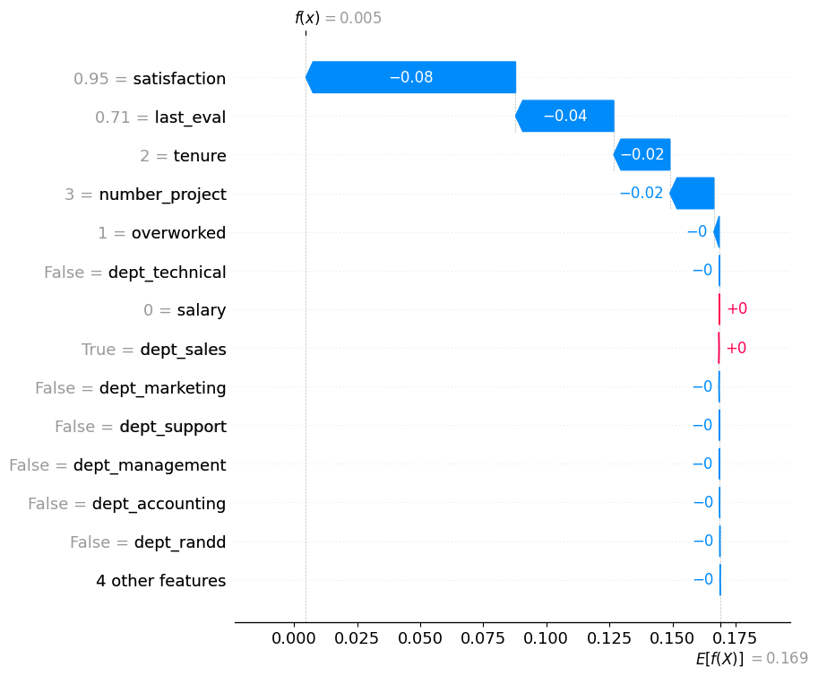

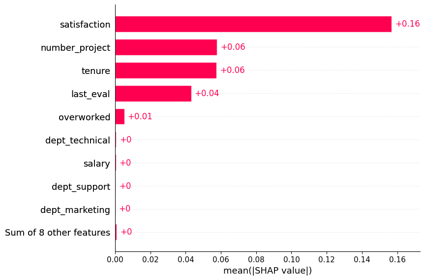

```python
explainer = shap.TreeExplainer(rf1_best_model)

# Calculate SHAP values for a specific observation
shap_values = explainer(X_test[:100])

shap_values = shap_values[..., 1]

# Plot the SHAP values for that observation

plt.grid(True, linestyle='--', alpha=0.7)
shap.summary_plot(shap_values, X_test[:100])

shap.plots.waterfall(shap_values[0], max_display=14)
shap.plots.bar(shap_values)
```

#### Classification Report

```python
classification_report_summary(model_prefix+' - '+dataset+' - '+'test', y_test, y_pred_test)
```

```
Classification Report :  rf1 - ALLFeat - test
                           precision    recall  f1-score   support

Predicted would not leave       0.98      0.99      0.99      2321
    Predicted would leave       0.96      0.92      0.94       471

                 accuracy                           0.98      2792
                macro avg       0.97      0.96      0.97      2792
             weighted avg       0.98      0.98      0.98      2792

Recall        : 0.92
f1_score      : 0.94
Precision     : 0.96
Accuracy      : 0.98

───────────────────────────────────
Weighted Average
───────────────────────────────────
Recall        : 0.98
f1 Score      : 0.98
Precision     : 0.98
Support       : 2792.00

───────────────────────────────────
Prediction F1 score
───────────────────────────────────
Predict Leave : 0.94
Support Stay  : 0.99
```

#### Format and Save model Scores - `model_rf1` - Test Data

```python
model_rf1_results = make_lr_results(model_prefix+' - '+dataset+' - '+'test', rf1_best_model, X_test, y_test, y_pred_test)
model_rf1_results.to_csv("./Results.csv", mode='a', index=True, header=False)
```

#### Display Results

```python
print(model_rf1_results)
print()
display_results()
```

```
                  Model  Precision  Recall     F1  Accuracy    AUC  Predict Leave  Predict Stay
0  rf1 - ALLFeat - test     0.9810  0.9810 0.9810    0.9810 0.9830         0.9430        0.9890
```

|  | Model | Precision | Recall | F1 | Accuracy | AUC | Predict Leave | Predict Stay |
| --- | --- | --- | --- | --- | --- | --- | --- | --- |
| 19 | rf1 - ALLFeat - test | 0.9810 | 0.9810 | 0.9810 | 0.9810 | 0.9830 | 0.9430 | 0.9890 |
| 11 | rf1 - ALLFeat - test | 0.9810 | 0.9810 | 0.9810 | 0.9810 | 0.9830 | 0.9430 | 0.9890 |
| 17 | rf1 - ALLFeat - test | 0.9810 | 0.9810 | 0.9810 | 0.9810 | 0.9830 | 0.9430 | 0.9890 |
| 15 | rf2 - NOdept - test | 0.9810 | 0.9810 | 0.9810 | 0.9810 | 0.9830 | 0.9430 | 0.9890 |
| 13 | rf1 - ALLFeat - test | 0.9810 | 0.9810 | 0.9810 | 0.9810 | 0.9830 | 0.9430 | 0.9890 |
| 14 | rf2 - NOdept - GS train | 0.9640 | 0.9090 | 0.9350 | 0.9790 | 0.9810 | NaN | NaN |
| 18 | rf1 - ALLFeat - GS train | 0.9640 | 0.9080 | 0.9350 | 0.9790 | 0.9800 | NaN | NaN |
| 16 | rf1 - ALLFeat - GS train | 0.9640 | 0.9080 | 0.9350 | 0.9790 | 0.9800 | NaN | NaN |
| 12 | rf1 - ALLFeat - GS train | 0.9640 | 0.9080 | 0.9350 | 0.9790 | 0.9800 | NaN | NaN |
| 10 | rf1 - ALLFeat - GS train | 0.9640 | 0.9080 | 0.9350 | 0.9790 | 0.9800 | NaN | NaN |
| 9 | dt2 - NOdept - train | 0.9780 | 0.9790 | 0.9780 | 0.9790 | 0.9790 | 0.9350 | 0.9870 |
| 8 | dt2 - NOdept - test | 0.9780 | 0.9790 | 0.9780 | 0.9790 | 0.9790 | 0.9360 | 0.9870 |
| 6 | dt1 - ALLFeat - train | 0.9780 | 0.9790 | 0.9780 | 0.9790 | 0.9790 | 0.9350 | 0.9870 |
| 5 | dt1 - ALLFeat - test | 0.9780 | 0.9790 | 0.9780 | 0.9790 | 0.9790 | 0.9360 | 0.9870 |
| 7 | dt2 - NOdept - GS train | 0.9510 | 0.9140 | 0.9320 | 0.9770 | 0.9740 | NaN | NaN |
| 4 | dt1 - ALLFeat - GS train | 0.9510 | 0.9140 | 0.9320 | 0.9770 | 0.9740 | NaN | NaN |
| 1 | lr1 - ALLFeat - train | 0.7740 | 0.8130 | 0.7860 | 0.8130 | 0.8870 | 0.2580 | 0.8930 |
| 3 | lr2 - NOdept - train | 0.7700 | 0.8110 | 0.7830 | 0.8110 | 0.8860 | 0.2470 | 0.8920 |
| 2 | lr2 - NOdept - test | 0.7670 | 0.8060 | 0.7810 | 0.8060 | 0.8780 | 0.2480 | 0.8890 |
| 0 | lr1 - ALLFeat - test | 0.7760 | 0.8110 | 0.7880 | 0.8110 | 0.8780 | 0.2770 | 0.8910 |

### Display Results - Random Forest Confusion Matrix

|  | Predicted `left = 0` | Predicted `left = 1` |
| --- | --- | --- |

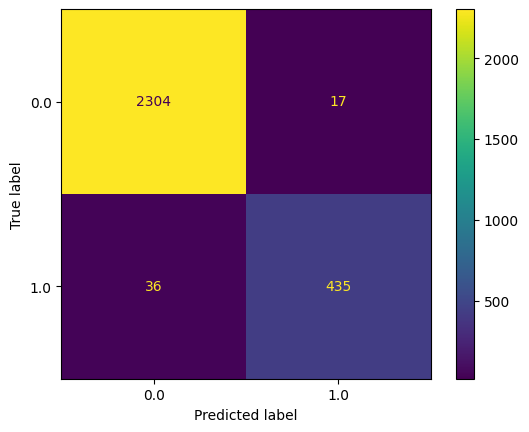

```python
# Generate array of values for confusion matrix
#preds = rf2.best_estimator_.predict(X_test)
cm = confusion_matrix(y_test, y_pred_test, labels=rf1_best_model.classes_)

# Plot confusion matrix
disp = ConfusionMatrixDisplay(confusion_matrix=cm,
                             display_labels=rf1_best_model.classes_)
disp.plot(values_format='');
```

### Display Results - Random Forest Feature Importance

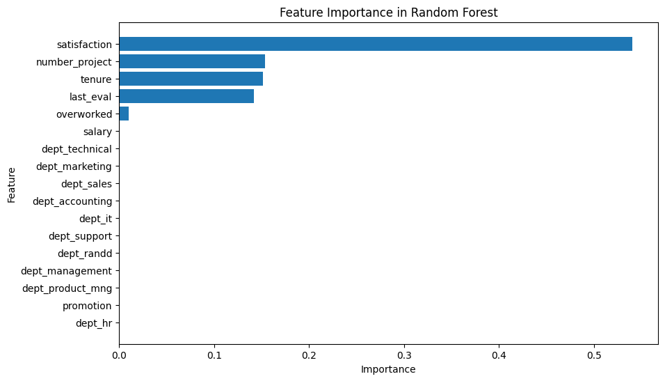

```python
#tree2_importances = pd.DataFrame(tree2.best_estimator_.feature_importances_, columns=X.columns)
# Get feature importances (Gini importance)
feature_importance = rf1_best_model.feature_importances_

# Get the names of the features
feature_names = X.columns  # Replace with your feature names

# Create a DataFrame to store feature names and their Gini importance
importance_df = pd.DataFrame({'Feature': feature_names, 'Feature Importance': feature_importance})

# Sort the DataFrame by Gini importance in descending order
importance_df = importance_df.sort_values(by='Feature Importance', ascending=True)

# Plot the Gini importance values
plt.figure(figsize=(10, 6))
plt.barh(importance_df['Feature'], importance_df['Feature Importance'])
plt.xlabel('Importance')
plt.ylabel('Feature')
plt.title('Feature Importance in Random Forest')
plt.show()
```

```python
# Get feature importances
importances = rf1_best_model.feature_importances_

# Get the indices that would sort the importances in descending order
indices = np.argsort(importances)[::-1]

# Print feature importances in descending order
for f in range(X.shape[1]):
    print(f"{X.columns[indices[f]]:19} : {importances[indices[f]]:15.4f}")
```

```
satisfaction        :          0.5404
number_project      :          0.1536
tenure              :          0.1514
last_eval           :          0.1421
overworked          :          0.0104
salary              :          0.0006
dept_technical      :          0.0003
dept_marketing      :          0.0002
dept_sales          :          0.0002
dept_accounting     :          0.0002
dept_it             :          0.0002
dept_support        :          0.0002
dept_randd          :          0.0001
dept_management     :          0.0001
dept_product_mng    :          0.0000
promotion           :          0.0000
dept_hr             :          0.0000
```

## Random Forest - `rf2` - No Departments

### Import Data - `rf2` - No Departments

Two datasets for model performance comparison, :

- `data_cleaned_NoOl_FE_AllFeat.csv` is the full data set feature engineered with `salary` encoded to ordinal, `avg_mth_hrs` binary encoded to `overwork` and dept encoded with dummies
- `data_cleaned_NoOl_FE_NoDept.csv` (THIS DATA) is the same data with the dummy encoded dept fields removed.

`Dept` appears to have low correlation across the dataset and I'm curious how much the models are influenced with low correlation features. It turns out that low correlation features have little impact on model performance. which is no surprise really!

### Code flags:

**rerun** = flag to identify the first run of the model comparisons and write a NEW Results.csv file. 0 = first run and a new file will be created with headers / 1 = Continuation, Results will be appended to the file.

**dataset** = Text indicating which dataset is being used, added to the model description during csv save to Results.csv

**model_prefix** = text indicating which ML model is being used, added to the model description during csv save to Results.csv

**refit** = Random Forest fits with this data takes 20-30 mins. 1 = Fit Data and Pickle Save Model 0 = don't refit data, Pickle load model

**fitver** = suffix added to pickle save model file name to help distinguish rf1/rf2 and all feature or focus features datasets

```python
# Load cleaned dataset into a dataframe
print("Started / Last Run =", dt.now().strftime("%Y-%m-%d %H:%M:%S"),"\n")

# Feature engineering on salary, avg_mnth_hrs, outliers removed, departments removed
df2 = pd.read_csv(load_path + "data_cleaned_NoOl_FE_NoDept.csv", index_col = False)

# model_prefix : Str prefix for results.csv added to dataset
model_prefix   = 'rf2'

# dataset : Str = dataset save name for results.csv
dataset        = 'NOdept'

# fitver : Str = Suffix for the pickle save filename
fitver         = 'NOdept'

# rerun : int =  Flag to set 1 = append to Results.csv / 0 = Overwrite with new file
rerun          = 1

# refit : int - 1 = Fit Data and Save model / 0 = load model, don't fit data
refit          = 0         # 1 = Fit Data and Save model / 0 = load model, don't fit data

print("df2 - FOCUS FEATURES - Feature engineering on salary, avg_mnth_hrs, dept REMOVED, outliers removed\n")

# Display dataframe columns
print(df2.info())
```

```
Started / Last Run = 2023-11-23 09:43:20

df2 - FOCUS FEATURES - Feature engineering on salary, avg_mnth_hrs, dept REMOVED, outliers removed

<class 'pandas.core.frame.DataFrame'>
RangeIndex: 11167 entries, 0 to 11166
Data columns (total 8 columns):
 #   Column          Non-Null Count  Dtype
---  ------          --------------  -----
 0   satisfaction    11167 non-null  float64
 1   last_eval       11167 non-null  float64
 2   number_project  11167 non-null  float64
 3   overworked      11167 non-null  int64
 4   tenure          11167 non-null  float64
 5   left            11167 non-null  float64
 6   promotion       11167 non-null  float64
 7   salary          11167 non-null  int64
dtypes: float64(6), int64(2)
memory usage: 698.1 KB
None
```

### Prepare data for modelling - `rf2`

```python
model_data2 = df2.copy()
```

### Isolate the outcome and feature variables - `rf2`

```python
# Isolate the outcome variable
Y2 = model_data2['left']

# Select & Isolate the feature variables and drop the outcome variable
X2 = model_data2.copy()
X2 = X2.drop('left', axis = 1)

#X = sm.add_constant(X)

X2.columns
```

```
Index(['satisfaction', 'last_eval', 'number_project', 'overworked', 'tenure', 'promotion', 'salary'], dtype='object')
```

### Train / Test split - `rf2`

```python
# Prepare training and test data
X_train2, X_test2, y_train2, y_test2 = train_test_split(X2,Y2, test_size=0.25, stratify=Y, random_state=0)
```

### Instantiate model - Random Forest - GridSearch - `model_rf2` - Train data

```python
# Instantiate model
rfc = RandomForestClassifier(random_state=0)

# Assign a dictionary of hyperparameters to search over
cv_params = {'max_depth': [3,5, None],
             'max_features': [1.0],
             'max_samples': [0.7, 1.0],
             'min_samples_leaf': [1,2,3],
             'min_samples_split': [2,3,4],
             'n_estimators': [300, 500],
             }

# Assign a dictionary of scoring metrics to capture
scoring = ('accuracy', 'precision', 'recall', 'f1', 'roc_auc')

# Instantiate GridSearch
model_rf2 = GridSearchCV(rfc, cv_params, scoring=scoring, cv=4, refit='roc_auc')
```

### Fit Data - Random Forest - Grid Search - `model_rf2` - Train data

```python
%%time
print("Started / Last Run =", dt.now().strftime("%Y-%m-%d %H:%M:%S"))
# Fit data
if refit == 1:
    model_rf2.fit(X_train2, y_train2) # --> Wall time: 21min 5s
    beepr()

print("Finish Time =", dt.now().strftime("%H:%M:%S"))
```

```
Started / Last Run = 2023-11-23 09:43:20
Finish Time = 09:43:20
CPU times: user 202 µs, sys: 54 µs, total: 256 µs
Wall time: 216 µs
```

#### Read / Write Pickle

```python
print(refit)
```

```
0
```

```python
## Write pickle

if refit == 1: # refit = 1 run the fit and save the model
    write_pickle(model_path, model_rf2, 'hr_rf2-'+fitver)

# Read in pickle
if refit == 0: # refit = 0 load model, don't  fit the data
    model_rf2 = read_pickle(model_path, 'hr_rf2-'+fitver)
```

#### Get GridSearch best results - Random Forest - `model_rf2` - Train data

```python
# Get the parameters of the best-performing model
print("Best Parameters : ", model_rf2.best_params_)

# Get the average f1 score of the best-performing model
print("Best Score      : ", model_rf2.best_score_)

# Get the best estimators of the parameters
print("Best Estimator  : ", model_rf2.best_estimator_)
```

```
Best Parameters :  {'max_depth': 5, 'max_features': 1.0, 'max_samples': 0.7, 'min_samples_leaf': 3, 'min_samples_split': 2, 'n_estimators': 300}
Best Score      :  0.9807690341320501
Best Estimator  :  RandomForestClassifier(max_depth=5, max_features=1.0, max_samples=0.7,
                       min_samples_leaf=3, n_estimators=300, random_state=0)
```

#### Format and Save model Scores - Random Forest - GridSearch - `model_rf2` - Train data

```python
pd.options.display.float_format = '{:.3f}'.format
model_rf2_results = format_GS_results(model_prefix+' - '+dataset+' - '+'GS train', model_rf2, 'auc')
model_rf2_results.to_csv("./Results.csv", mode='a', index=True, header=False)
```

#### Display Results

```python
pd.options.display.float_format = '{:.3f}'.format
print(model_rf2_results)
display_results()
```

```
                     Model  Precision  Recall    F1  Accuracy   AUC
0  rf2 - NOdept - GS train      0.964   0.909 0.935     0.979 0.981
```

|  | Model | Precision | Recall | F1 | Accuracy | AUC | Predict Leave | Predict Stay |
| --- | --- | --- | --- | --- | --- | --- | --- | --- |
| 11 | rf1 - ALLFeat - test | 0.981 | 0.981 | 0.981 | 0.981 | 0.983 | 0.943 | 0.989 |
| 19 | rf1 - ALLFeat - test | 0.981 | 0.981 | 0.981 | 0.981 | 0.983 | 0.943 | 0.989 |
| 17 | rf1 - ALLFeat - test | 0.981 | 0.981 | 0.981 | 0.981 | 0.983 | 0.943 | 0.989 |
| 15 | rf2 - NOdept - test | 0.981 | 0.981 | 0.981 | 0.981 | 0.983 | 0.943 | 0.989 |
| 13 | rf1 - ALLFeat - test | 0.981 | 0.981 | 0.981 | 0.981 | 0.983 | 0.943 | 0.989 |
| 20 | rf2 - NOdept - GS train | 0.964 | 0.909 | 0.935 | 0.979 | 0.981 | NaN | NaN |
| 14 | rf2 - NOdept - GS train | 0.964 | 0.909 | 0.935 | 0.979 | 0.981 | NaN | NaN |
| 18 | rf1 - ALLFeat - GS train | 0.964 | 0.908 | 0.935 | 0.979 | 0.980 | NaN | NaN |
| 16 | rf1 - ALLFeat - GS train | 0.964 | 0.908 | 0.935 | 0.979 | 0.980 | NaN | NaN |
| 12 | rf1 - ALLFeat - GS train | 0.964 | 0.908 | 0.935 | 0.979 | 0.980 | NaN | NaN |
| 10 | rf1 - ALLFeat - GS train | 0.964 | 0.908 | 0.935 | 0.979 | 0.980 | NaN | NaN |
| 9 | dt2 - NOdept - train | 0.978 | 0.979 | 0.978 | 0.979 | 0.979 | 0.935 | 0.987 |
| 8 | dt2 - NOdept - test | 0.978 | 0.979 | 0.978 | 0.979 | 0.979 | 0.936 | 0.987 |
| 6 | dt1 - ALLFeat - train | 0.978 | 0.979 | 0.978 | 0.979 | 0.979 | 0.935 | 0.987 |
| 5 | dt1 - ALLFeat - test | 0.978 | 0.979 | 0.978 | 0.979 | 0.979 | 0.936 | 0.987 |
| 7 | dt2 - NOdept - GS train | 0.951 | 0.914 | 0.932 | 0.977 | 0.974 | NaN | NaN |
| 4 | dt1 - ALLFeat - GS train | 0.951 | 0.914 | 0.932 | 0.977 | 0.974 | NaN | NaN |
| 1 | lr1 - ALLFeat - train | 0.774 | 0.813 | 0.786 | 0.813 | 0.887 | 0.258 | 0.893 |
| 3 | lr2 - NOdept - train | 0.770 | 0.811 | 0.783 | 0.811 | 0.886 | 0.247 | 0.892 |
| 2 | lr2 - NOdept - test | 0.767 | 0.806 | 0.781 | 0.806 | 0.878 | 0.248 | 0.889 |
| 0 | lr1 - ALLFeat - test | 0.776 | 0.811 | 0.788 | 0.811 | 0.878 | 0.277 | 0.891 |

### Make Predictions - Random Forest - best_model - `model_rf2` - Test data

```python
# Make predictions on test data

# Store best model parameters for later testing
rf2_best_model = model_rf2.best_estimator_
y_pred_test2 = rf2_best_model.predict(X_test2)
```

#### Classification Report

```python
classification_report_summary(model_prefix+' - '+dataset+' - '+'test', y_test2, y_pred_test2)
```

```
Classification Report :  rf2 - NOdept - test
                           precision    recall  f1-score   support

Predicted would not leave       0.98      0.99      0.99      2321
    Predicted would leave       0.96      0.92      0.94       471

                 accuracy                           0.98      2792
                macro avg       0.97      0.96      0.97      2792
             weighted avg       0.98      0.98      0.98      2792

Recall        : 0.92
f1_score      : 0.94
Precision     : 0.96
Accuracy      : 0.98

───────────────────────────────────
Weighted Average
───────────────────────────────────
Recall        : 0.98
f1 Score      : 0.98
Precision     : 0.98
Support       : 2792.00

───────────────────────────────────
Prediction F1 score
───────────────────────────────────
Predict Leave : 0.94
Support Stay  : 0.99
```

#### Format and Save model Scores - Random Forest TEST

```python
model_rf2_results = make_lr_results(model_prefix+' - '+dataset+' - '+'test', rf2_best_model, X_test2, y_test2, y_pred_test2)
model_rf2_results.to_csv("./Results.csv", mode='a', index=True, header=False)
```

#### Display Results

```python
print(model_rf2_results)
print()
display_results()
```

```
                 Model  Precision  Recall    F1  Accuracy   AUC  Predict Leave  Predict Stay
0  rf2 - NOdept - test      0.981   0.981 0.981     0.981 0.983          0.943         0.989
```

|  | Model | Precision | Recall | F1 | Accuracy | AUC | Predict Leave | Predict Stay |
| --- | --- | --- | --- | --- | --- | --- | --- | --- |
| 11 | rf1 - ALLFeat - test | 0.981 | 0.981 | 0.981 | 0.981 | 0.983 | 0.943 | 0.989 |
| 13 | rf1 - ALLFeat - test | 0.981 | 0.981 | 0.981 | 0.981 | 0.983 | 0.943 | 0.989 |
| 19 | rf1 - ALLFeat - test | 0.981 | 0.981 | 0.981 | 0.981 | 0.983 | 0.943 | 0.989 |
| 17 | rf1 - ALLFeat - test | 0.981 | 0.981 | 0.981 | 0.981 | 0.983 | 0.943 | 0.989 |
| 15 | rf2 - NOdept - test | 0.981 | 0.981 | 0.981 | 0.981 | 0.983 | 0.943 | 0.989 |
| 21 | rf2 - NOdept - test | 0.981 | 0.981 | 0.981 | 0.981 | 0.983 | 0.943 | 0.989 |
| 14 | rf2 - NOdept - GS train | 0.964 | 0.909 | 0.935 | 0.979 | 0.981 | NaN | NaN |
| 20 | rf2 - NOdept - GS train | 0.964 | 0.909 | 0.935 | 0.979 | 0.981 | NaN | NaN |
| 10 | rf1 - ALLFeat - GS train | 0.964 | 0.908 | 0.935 | 0.979 | 0.980 | NaN | NaN |
| 12 | rf1 - ALLFeat - GS train | 0.964 | 0.908 | 0.935 | 0.979 | 0.980 | NaN | NaN |
| 16 | rf1 - ALLFeat - GS train | 0.964 | 0.908 | 0.935 | 0.979 | 0.980 | NaN | NaN |
| 18 | rf1 - ALLFeat - GS train | 0.964 | 0.908 | 0.935 | 0.979 | 0.980 | NaN | NaN |
| 6 | dt1 - ALLFeat - train | 0.978 | 0.979 | 0.978 | 0.979 | 0.979 | 0.935 | 0.987 |
| 8 | dt2 - NOdept - test | 0.978 | 0.979 | 0.978 | 0.979 | 0.979 | 0.936 | 0.987 |
| 9 | dt2 - NOdept - train | 0.978 | 0.979 | 0.978 | 0.979 | 0.979 | 0.935 | 0.987 |
| 5 | dt1 - ALLFeat - test | 0.978 | 0.979 | 0.978 | 0.979 | 0.979 | 0.936 | 0.987 |
| 7 | dt2 - NOdept - GS train | 0.951 | 0.914 | 0.932 | 0.977 | 0.974 | NaN | NaN |
| 4 | dt1 - ALLFeat - GS train | 0.951 | 0.914 | 0.932 | 0.977 | 0.974 | NaN | NaN |
| 1 | lr1 - ALLFeat - train | 0.774 | 0.813 | 0.786 | 0.813 | 0.887 | 0.258 | 0.893 |
| 3 | lr2 - NOdept - train | 0.770 | 0.811 | 0.783 | 0.811 | 0.886 | 0.247 | 0.892 |
| 2 | lr2 - NOdept - test | 0.767 | 0.806 | 0.781 | 0.806 | 0.878 | 0.248 | 0.889 |
| 0 | lr1 - ALLFeat - test | 0.776 | 0.811 | 0.788 | 0.811 | 0.878 | 0.277 | 0.891 |

### Display Results - Random Forest Confusion Matrix

|  | Predicted `left = 0` | Predicted `left = 1` |
| --- | --- | --- |

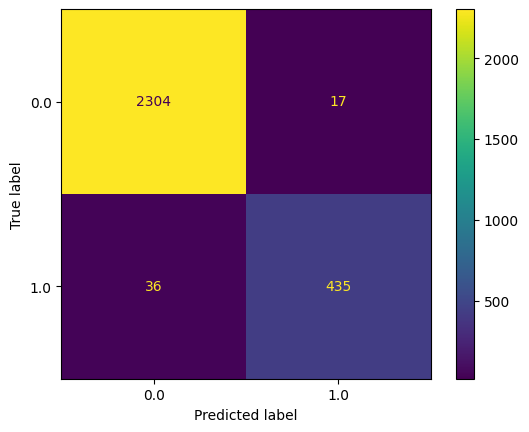

```python
# Generate array of values for confusion matrix
#preds = rf2.best_estimator_.predict(X_test)
cm = confusion_matrix(y_test2, y_pred_test2, labels=model_rf2.classes_)

# Plot confusion matrix
disp = ConfusionMatrixDisplay(confusion_matrix=cm,
                             display_labels=model_rf2.classes_)
disp.plot(values_format='');
```

### Display Results - Random Forest Feature Importance

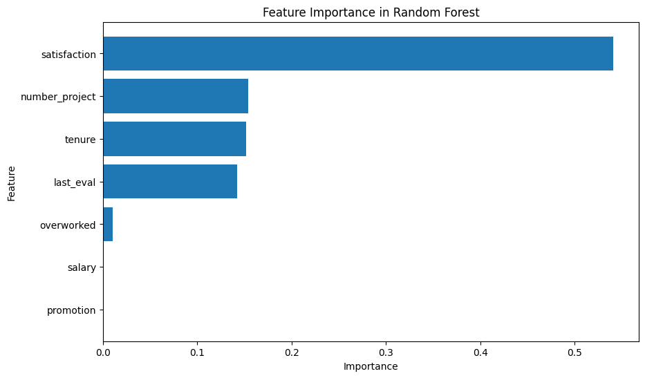

```python
#tree2_importances = pd.DataFrame(tree2.best_estimator_.feature_importances_, columns=X.columns)
# Get feature importances (Gini importance)
feature_importance = rf2_best_model.feature_importances_

# Get the names of the features
feature_names = X2.columns  # Replace with your feature names

# Create a DataFrame to store feature names and their Gini importance
importance_df = pd.DataFrame({'Feature': feature_names, 'Feature Importance': feature_importance})

# Sort the DataFrame by Gini importance in descending order
importance_df = importance_df.sort_values(by='Feature Importance', ascending=True)

# Plot the Gini importance values
plt.figure(figsize=(10, 6))
plt.barh(importance_df['Feature'], importance_df['Feature Importance'])
plt.xlabel('Importance')
plt.ylabel('Feature')
plt.title('Feature Importance in Random Forest')
plt.show()
```

```python
# Get feature importances
importances = rf2_best_model.feature_importances_

# Get the indices that would sort the importances in descending order
indices = np.argsort(importances)[::-1]

# Print feature importances in descending order
for f in range(X2.shape[1]):
    print(f"{X2.columns[indices[f]]:19} : {importances[indices[f]]:15.4f}")
```

```
satisfaction        :          0.5410
number_project      :          0.1538
tenure              :          0.1516
last_eval           :          0.1426
overworked          :          0.0104
salary              :          0.0007
promotion           :          0.0000
```

# Review Results

## Dataset comparison - Random Forest

There is little difference in performance between the two datasets.

- `ALLFeat` = complete feature engineered dataset
- `NoDept` = dataset with dummy encoded dept removed

## Model performance

```python
display_results()
```

|  | Model | Precision | Recall | F1 | Accuracy | AUC | Predict Leave | Predict Stay |
| --- | --- | --- | --- | --- | --- | --- | --- | --- |
| 11 | rf1 - ALLFeat - test | 0.981 | 0.981 | 0.981 | 0.981 | 0.983 | 0.943 | 0.989 |
| 13 | rf1 - ALLFeat - test | 0.981 | 0.981 | 0.981 | 0.981 | 0.983 | 0.943 | 0.989 |
| 19 | rf1 - ALLFeat - test | 0.981 | 0.981 | 0.981 | 0.981 | 0.983 | 0.943 | 0.989 |
| 17 | rf1 - ALLFeat - test | 0.981 | 0.981 | 0.981 | 0.981 | 0.983 | 0.943 | 0.989 |
| 15 | rf2 - NOdept - test | 0.981 | 0.981 | 0.981 | 0.981 | 0.983 | 0.943 | 0.989 |
| 21 | rf2 - NOdept - test | 0.981 | 0.981 | 0.981 | 0.981 | 0.983 | 0.943 | 0.989 |
| 14 | rf2 - NOdept - GS train | 0.964 | 0.909 | 0.935 | 0.979 | 0.981 | NaN | NaN |
| 20 | rf2 - NOdept - GS train | 0.964 | 0.909 | 0.935 | 0.979 | 0.981 | NaN | NaN |
| 10 | rf1 - ALLFeat - GS train | 0.964 | 0.908 | 0.935 | 0.979 | 0.980 | NaN | NaN |
| 12 | rf1 - ALLFeat - GS train | 0.964 | 0.908 | 0.935 | 0.979 | 0.980 | NaN | NaN |
| 16 | rf1 - ALLFeat - GS train | 0.964 | 0.908 | 0.935 | 0.979 | 0.980 | NaN | NaN |
| 18 | rf1 - ALLFeat - GS train | 0.964 | 0.908 | 0.935 | 0.979 | 0.980 | NaN | NaN |
| 6 | dt1 - ALLFeat - train | 0.978 | 0.979 | 0.978 | 0.979 | 0.979 | 0.935 | 0.987 |
| 8 | dt2 - NOdept - test | 0.978 | 0.979 | 0.978 | 0.979 | 0.979 | 0.936 | 0.987 |
| 9 | dt2 - NOdept - train | 0.978 | 0.979 | 0.978 | 0.979 | 0.979 | 0.935 | 0.987 |
| 5 | dt1 - ALLFeat - test | 0.978 | 0.979 | 0.978 | 0.979 | 0.979 | 0.936 | 0.987 |
| 7 | dt2 - NOdept - GS train | 0.951 | 0.914 | 0.932 | 0.977 | 0.974 | NaN | NaN |
| 4 | dt1 - ALLFeat - GS train | 0.951 | 0.914 | 0.932 | 0.977 | 0.974 | NaN | NaN |
| 1 | lr1 - ALLFeat - train | 0.774 | 0.813 | 0.786 | 0.813 | 0.887 | 0.258 | 0.893 |
| 3 | lr2 - NOdept - train | 0.770 | 0.811 | 0.783 | 0.811 | 0.886 | 0.247 | 0.892 |
| 2 | lr2 - NOdept - test | 0.767 | 0.806 | 0.781 | 0.806 | 0.878 | 0.248 | 0.889 |
| 0 | lr1 - ALLFeat - test | 0.776 | 0.811 | 0.788 | 0.811 | 0.878 | 0.277 | 0.891 |

F1, Precision, Recall and Accuracy are also within acceptable ranges

# Feature Importance

## Conclusion, model comparison - RandomForest.

Again, there is almost no difference to the performance of the two datasets (`AllFeat`/`NoDept`) when modelled through either Logistic Regression or Decision Tree. While there's a tiny improvement in RandomForest vs DecisionTree, there's almost no difference in feature importance.

SHAP and Feature importance are showing similar results with the ranking of importance :

- Satisfaction
- Number of Projects
- Tenure
- Last Eval Score
- Overworked flag

The department the employees works in has minimal bearing on these results.